# Time-varying case fatality risk

If you are unfamiliar with the {simulist} package or the `sim_linelist()` function Get Started vignette is a great place to start.

This vignette demonstrates how to simulate line list data using the time-varying case fatality risk and gives an overview of the methodological details.

The {simulist} R package uses an individual-based branching process simulation to generate contacts and cases for line list and contact tracing data. The time-varying case fatality risk feature provides a way to incorporate aspects of epidemics where the risk of death may decrease through time, potentially due to improved medical treatment, vaccination or viral evolution. It is also possible to model increasing case fatality risk through time, or a stepwise risk function where the risk of death shifts between states.

The time-varying case fatality risk implemented in this package is not meant to explicitly model these factors, but rather to give the user an option to more closely resemble fatality risk through the course of an epidemic, possibly because there is data on this, or just to simulate data that has these characteristics.

See the [{epidemics} R package](https://epiverse-trace.github.io/epidemics/index.html) for a population-level epidemic simulation package with explicit interventions and vaccinations.

Given that setting a time-varying case fatality risk is not needed for most use cases of the {simulist} R package, this feature uses the `config` argument in the `sim_*()` functions. Therefore, the time-varying case fatality risk can be set when calling `create_config()` (see below for details).

```r
library(simulist)
library(epiparameter)
library(tidyr)
library(dplyr)
library(incidence2)
library(ggplot2)
```

First we will demonstrate the default setting of a constant case fatality risk throughout an epidemic.

```r
contact_distribution <- epiparameter(
  disease = "COVID-19",
  epi_name = "contact distribution",
  prob_distribution = create_prob_distribution(
    prob_distribution = "pois",
    prob_distribution_params = c(mean = 2)
  )
)
```

```
#> Citation cannot be created as author, year, journal or title is missing
```

```r
infectious_period <- epiparameter(
  disease = "COVID-19",
  epi_name = "infectious period",
  prob_distribution = create_prob_distribution(
    prob_distribution = "gamma",
    prob_distribution_params = c(shape = 3, scale = 3)
  )
)
```

```
#> Citation cannot be created as author, year, journal or title is missing
```

```r
# get onset to hospital admission from {epiparameter} database
onset_to_hosp <- epiparameter(
  disease = "COVID-19",
  epi_name = "onset to hospitalisation",
  prob_distribution = create_prob_distribution(
    prob_distribution = "lnorm",
    prob_distribution_params = c(meanlog = 1, sdlog = 0.5)
  )
)
```

```
#> Citation cannot be created as author, year, journal or title is missing
```

```r
# get onset to death from {epiparameter} database
onset_to_death <- epiparameter_db(
  disease = "COVID-19",
  epi_name = "onset to death",
  single_epiparameter = TRUE
)
```

```
#> Using Linton N, Kobayashi T, Yang Y, Hayashi K, Akhmetzhanov A, Jung S, Yuan
#> B, Kinoshita R, Nishiura H (2020). "Incubation Period and Other
#> Epidemiological Characteristics of 2019 Novel Coronavirus Infections
#> with Right Truncation: A Statistical Analysis of Publicly Available
#> Case Data." _Journal of Clinical Medicine_. doi:10.3390/jcm9020538
#> <https://doi.org/10.3390/jcm9020538>..
#> To retrieve the citation use the 'get_citation' function
```

We set the seed to ensure we have the same output each time the vignette is rendered. When using {simulist}, setting the seed is not required unless you need to simulate the same line list multiple times.

```r
set.seed(1)
```

## Constant case fatality risk

When calling the `create_config()` function the default output contains a list element named `time_varying_death_risk` set to `NULL`. This corresponds to a constant case fatality risk over time, which is controlled by the `hosp_death_risk` and `non_hosp_death_risk` arguments. The defaults for these two arguments are:

- death risk when hospitalised (`hosp_death_risk`): `0.5` (50%)
- death risk outside of hospitals (`non_hosp_death_risk`): `0.05` (5%)

In this example we set them explicitly to be clear which risks we’re using, but otherwise the `hosp_death_risk`, `non_hosp_death_risk` and `config` do not need to be specified and can use their default values.

For all examples in this vignette we will set the epidemic size to be between 500 and 1,000 cases, to ensure that we can clearly see the case fatality patterns in the data.

See the Get Started vignette section on Controlling Outbreak Size for more information on this.

```r
linelist <- sim_linelist(
  contact_distribution = contact_distribution,
  infectious_period = infectious_period,
  prob_infection = 0.5,
  onset_to_hosp = onset_to_hosp,
  onset_to_death = onset_to_death,
  hosp_death_risk = 0.5,
  non_hosp_death_risk = 0.05,
  outbreak_size = c(500, 1000),
  config = create_config()
)

# first 6 rows of linelist
head(linelist)
```

```
#>   id          case_name case_type sex age date_onset date_reporting
#> 1  1  Reylando Yohannes  probable   m  40 2023-01-01     2023-01-01
#> 2  2         David Baca confirmed   m  12 2023-01-04     2023-01-04
#> 3  4     Kristopher Zhu  probable   m  45 2023-01-05     2023-01-05
#> 4  6 Muntasir al-Kaiser  probable   m  36 2023-01-07     2023-01-07
#> 5  7      Emma Kirscher  probable   f  42 2023-01-09     2023-01-09
#> 6  8           Jehan Ly confirmed   f  14 2023-01-08     2023-01-08
#>   date_admission   outcome date_outcome date_first_contact date_last_contact
#> 1           <NA> recovered         <NA>               <NA>              <NA>
#> 2           <NA> recovered         <NA>         2022-12-31        2023-01-04
#> 3           <NA> recovered         <NA>         2022-12-30        2023-01-04
#> 4     2023-01-09 recovered         <NA>         2023-01-03        2023-01-08
#> 5           <NA> recovered         <NA>         2023-01-01        2023-01-06
#> 6     2023-01-09 recovered         <NA>         2022-12-31        2023-01-08
#>   ct_value
#> 1       NA
#> 2     24.9
#> 3       NA
#> 4       NA
#> 5       NA
#> 6     26.3
```

To visualise the incidence of cases and deaths over time we will use the [{incidence2} R package](https://www.reconverse.org/incidence2/).

For more information on using {incidence2} to plot line list data see the Visualising simulated data vignette.

Before converting the line list `<data.frame>` to an `<incidence>` object we need to ungroup the outcome columns into their own columns using the [{tidyr}](https://tidyr.tidyverse.org/) and [{dplyr}](https://dplyr.tidyverse.org/) R packages from the [Tidyverse](https://www.tidyverse.org/).

```r
linelist <- linelist %>%
  pivot_wider(
    names_from = outcome,
    values_from = date_outcome
  ) %>%
  rename(
    date_death = died,
    date_recovery = recovered
  )
```

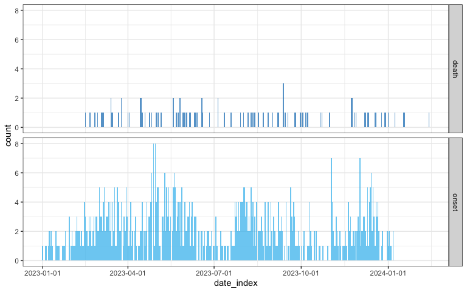

```r
daily <- incidence(
  linelist,
  date_index = c(
    onset = "date_onset",
    death = "date_death"
  ),
  interval = "daily",
  complete_dates = TRUE
)
plot(daily)
```

## Higher risk of case fatality

We repeat the above simulation but increase the risk of case fatality for both hospitalised (`hosp_death_risk`) and non-hospitalised (`non_hosp_death_risk`) individuals infected.

```r
linelist <- sim_linelist(
  contact_distribution = contact_distribution,
  infectious_period = infectious_period,
  prob_infection = 0.5,
  onset_to_hosp = onset_to_hosp,
  onset_to_death = onset_to_death,
  hosp_death_risk = 0.9,
  non_hosp_death_risk = 0.75,
  outbreak_size = c(500, 1000),
  config = create_config()
)
head(linelist)
```

```
#>   id             case_name case_type sex age date_onset date_reporting
#> 1  1 Christopher Bishop Jr confirmed   m  42 2023-01-01     2023-01-01
#> 2  2         Sophie Nedved confirmed   f  25 2023-01-06     2023-01-06
#> 3  4          Bianca Doell suspected   f  64 2023-01-07     2023-01-07
#> 4  6          Brandy Allen confirmed   f  46 2023-01-09     2023-01-09
#> 5  8    Zakiyya el-Shareef suspected   f  78 2023-01-08     2023-01-08
#> 6 10              Xai Yang suspected   m  13 2023-01-15     2023-01-15
#>   date_admission   outcome date_outcome date_first_contact date_last_contact
#> 1     2023-01-05 recovered         <NA>               <NA>              <NA>
#> 2     2023-01-09      died   2023-02-26         2022-12-31        2023-01-03
#> 3           <NA>      died   2023-01-27         2023-01-01        2023-01-08
#> 4           <NA>      died   2023-01-23         2023-01-04        2023-01-07
#> 5           <NA> recovered         <NA>         2023-01-05        2023-01-11
#> 6           <NA> recovered         <NA>         2023-01-06        2023-01-11
#>   ct_value
#> 1     19.6
#> 2     28.7
#> 3       NA
#> 4     21.7
#> 5       NA
#> 6       NA
```

```r
linelist <- linelist %>%
  pivot_wider(
    names_from = outcome,
    values_from = date_outcome
  ) %>%
  rename(
    date_death = died,
    date_recovery = recovered
  )
```

```r
daily <- incidence(
  linelist,
  date_index = c(
    onset = "date_onset",
    death = "date_death"
  ),
  interval = "daily",
  complete_dates = TRUE
)
```

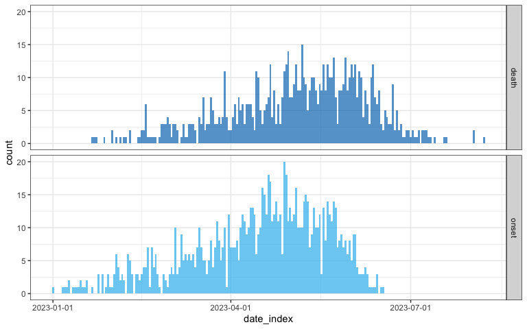

```r
plot(daily)
```

## Continuous time-varying case fatality risk

Now we’ve seen what the constant case fatality risk simulations look like, we can simulate with a time-varying function for the risk.

This is setup by calling the `create_config()` function, and providing an anonymous function with two arguments, `risk` and `time`, to `time_varying_death_risk`. This function will then use the relevant risk (e.g. `hosp_death_risk`) and the time an individual is infected and calculates the probability (or risk) of death.

The `create_config()` function has no named arguments, and the argument you are modifying needs to be matched by name exactly (case sensitive). See `?create_config()` for documentation.

```r
config <- create_config(
  time_varying_death_risk = function(risk, time) risk * exp(-0.05 * time)
)
```

```r
exp_df <- data.frame(
  time = 1:150,
  value = config$time_varying_death_risk(risk = 0.9, time = 1:150)
)
```

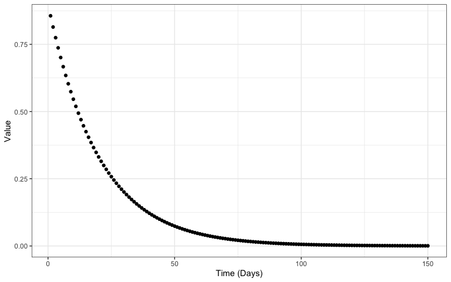

```r
ggplot(exp_df) +
  geom_point(mapping = aes(x = time, y = value)) +
  scale_y_continuous(name = "Value") +
  scale_x_continuous(name = "Time (Days)") +
  theme_bw()
```

The time-varying hospitalised case fatality risk function (`config$time_varying_death_risk`) throughout the epidemic. In this case the hospitalised risks (`hosp_death_risk`) are at their maximum value at day 0 and decline through time, with risk approaching zero at around day 100.

*Advanced*

The time-varying case fatality risk function modifies the the death risk specified by `hosp_death_risk` and `non_hosp_death_risk`. In this example, the user-supplied `hosp_death_risk` and `non_hosp_death_risk` are the maximum values, because the user-supplied time-varying function is declining over time, however, a user-supplied function may also increase over time, or fluctuate. The requirements are that the time-varying case fatality risk for both hospitalised and non-hospitalised infections must be between 0 and 1, otherwise the function will error.

In the example below `hosp_death_risk` is `0.9` and `non_hosp_death_risk` is `0.75`, and the time-varying case fatality risk function is an exponential decline. This means that on day 0 of the epidemic (i.e. first infection seeds the outbreak) the risks will be `0.9` and `0.75`. But any time after the start of the epidemic ($t_0 + \Delta t$) the risks will be lower, and when the exponential function approaches zero the risk of a case dying will also go to zero.

Simulating with the time-varying case fatality risk:

```r
linelist <- sim_linelist(
  contact_distribution = contact_distribution,
  infectious_period = infectious_period,
  prob_infection = 0.5,
  onset_to_hosp = onset_to_hosp,
  onset_to_death = onset_to_death,
  hosp_death_risk = 0.9,
  non_hosp_death_risk = 0.75,
  outbreak_size = c(500, 1000),
  config = config
)

head(linelist)
```

```
#>   id              case_name case_type sex age date_onset date_reporting
#> 1  1 Eduardo Avalos Chavira confirmed   m  59 2023-01-01     2023-01-01
#> 2  2    Danielle Lopez-Shue confirmed   f   2 2023-01-06     2023-01-06
#> 3  3          Rebecca Begay suspected   f  14 2023-01-02     2023-01-02
#> 4  6          Miguel Cortez  probable   m  49 2023-01-07     2023-01-07
#> 5  8            Cam Tu Reed  probable   f  22 2023-01-08     2023-01-08
#> 6 11            Kyla Tafoya suspected   f  40 2023-01-04     2023-01-04
#>   date_admission outcome date_outcome date_first_contact date_last_contact
#> 1           <NA>    died   2023-01-19               <NA>              <NA>
#> 2     2023-01-09    died   2023-02-01         2022-12-30        2023-01-07
#> 3           <NA>    died   2023-01-31         2022-12-31        2023-01-04
#> 4           <NA>    died   2023-01-26         2023-01-05        2023-01-08
#> 5     2023-01-11    died   2023-01-22         2023-01-03        2023-01-08
#> 6           <NA>    died   2023-01-13         2022-12-27        2023-01-06
#>   ct_value
#> 1     26.2
#> 2     25.7
#> 3       NA
#> 4       NA
#> 5       NA
#> 6       NA
```

```r
linelist <- linelist %>%
  pivot_wider(
    names_from = outcome,
    values_from = date_outcome
  ) %>%
  rename(
    date_death = died,
    date_recovery = recovered
  )
```

```r
daily <- incidence(
  linelist,
  date_index = c(
    onset = "date_onset",
    death = "date_death"
  ),
  interval = "daily",
  complete_dates = TRUE
)
```

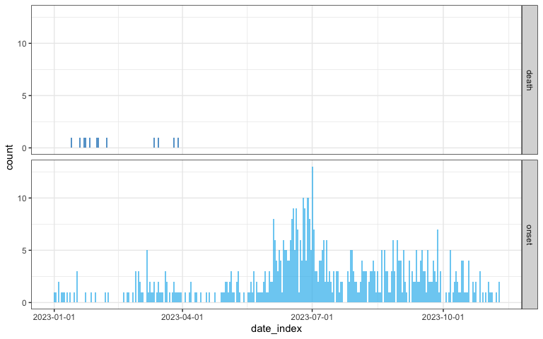

```r
plot(daily)
```

## Stepwise time-varying case fatality risk

In addition to a continuously varying case fatality risk function, the simulation can also work with stepwise (or piecewise) functions. This is where the risk will instantaneously change at a given point in time to another risk level.

To achieve this, we again specify an anonymous function in `create_config()`, but have the risk of a case dying set as the baseline `hosp_death_risk` and `non_hosp_death_risk` for the first 60 days of the outbreak and then become zero (i.e. if an individual is infected after day 60 they will definitely recover).

```r
config <- create_config(
  time_varying_death_risk = function(risk, time) ifelse(test = time < 60, yes = risk, no = 0)
)
```

```r
stepwise_df <- data.frame(
  time = 1:150,
  value = config$time_varying_death_risk(risk = 0.9, time = 1:150)
)
```

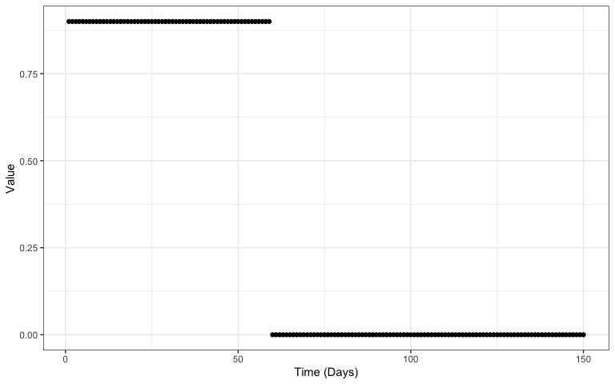

```r
ggplot(stepwise_df) +
  geom_point(mapping = aes(x = time, y = value)) +
  scale_y_continuous(name = "Value") +
  scale_x_continuous(name = "Time (Days)") +
  theme_bw()
```

The time-varying case fatality risk function (`config$time_varying_death_risk`) for the hospitalised death risk (`hosp_death_risk`) and non-hospitalised death risk (`non_hosp_death_risk`) throughout the epidemic. In this case the risks are at their user-supplied values from day 0 to day 60, and then become 0 onwards.

Simulating with the stepwise time-varying case fatality risk:

```r
linelist <- sim_linelist(
  contact_distribution = contact_distribution,
  infectious_period = infectious_period,
  prob_infection = 0.5,
  onset_to_hosp = onset_to_hosp,
  onset_to_death = onset_to_death,
  hosp_death_risk = 0.9,
  non_hosp_death_risk = 0.75,
  outbreak_size = c(500, 1000),
  config = config
)

head(linelist)
```

```
#>   id          case_name case_type sex age date_onset date_reporting
#> 1  1    Lannis Crossley confirmed   f  54 2023-01-01     2023-01-01
#> 2  2 Brittany Masteller confirmed   f  44 2023-01-05     2023-01-05
#> 3  4   Hamood al-Jabara confirmed   m  69 2023-01-07     2023-01-07
#> 4  5    Vanessa Salazar suspected   f  29 2023-01-11     2023-01-11
#> 5  6  Domineque Matthes confirmed   f  16 2023-01-10     2023-01-10
#> 6  8       Ana Melendez suspected   f  71 2023-01-09     2023-01-09
#>   date_admission   outcome date_outcome date_first_contact date_last_contact
#> 1           <NA> recovered         <NA>               <NA>              <NA>
#> 2           <NA> recovered         <NA>         2022-12-26        2023-01-03
#> 3     2023-01-08      died   2023-01-15         2022-12-26        2023-01-02
#> 4           <NA>      died   2023-03-06         2023-01-02        2023-01-09
#> 5           <NA>      died   2023-01-25         2023-01-03        2023-01-07
#> 6           <NA>      died   2023-01-14         2023-01-03        2023-01-09
#>   ct_value
#> 1     27.3
#> 2     23.5
#> 3     26.4
#> 4       NA
#> 5     25.9
#> 6       NA
```

```r
linelist <- linelist %>%
  pivot_wider(
    names_from = outcome,
    values_from = date_outcome
  ) %>%
  rename(
    date_death = died,
    date_recovery = recovered
  )
```

```r
daily <- incidence(
  linelist,
  date_index = c(
    onset = "date_onset",
    death = "date_death"
  ),
  interval = "daily",
  complete_dates = TRUE
)
```

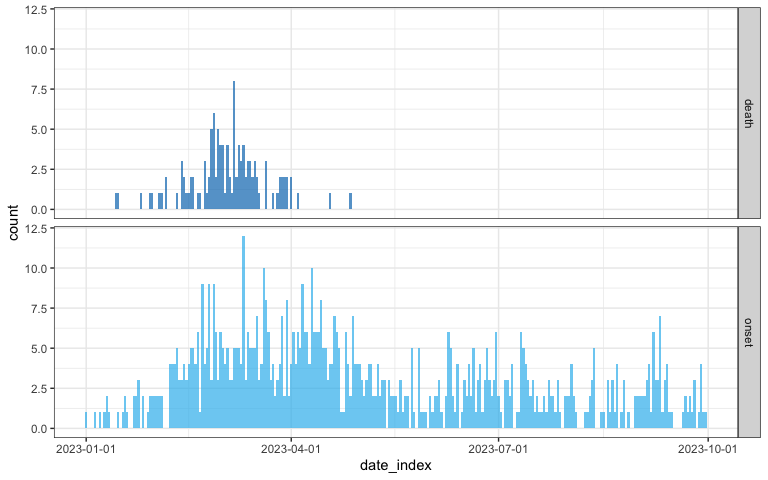

```r
plot(daily)
```

The same stepwise function can also be used to specify time windows were the risk of death is reduced. Here we specify the `hosp_death_risk` and `non_hosp_death_risk` in the first 50 days of the epidemic, then between day 50 and day 100 the risk is reduced by half, and then from day 100 onwards the risk goes back to the rates specified by `hosp_death_risk` and `non_hosp_death_risk`.

```r
config <- create_config(
  time_varying_death_risk = function(risk, time) {
    ifelse(test = time > 50 & time < 100, yes = risk * 0.5, no = risk)
  }
)
```

```r
stepwise_df <- data.frame(
  time = 1:150,
  value = config$time_varying_death_risk(risk = 0.9, time = 1:150)
)
```

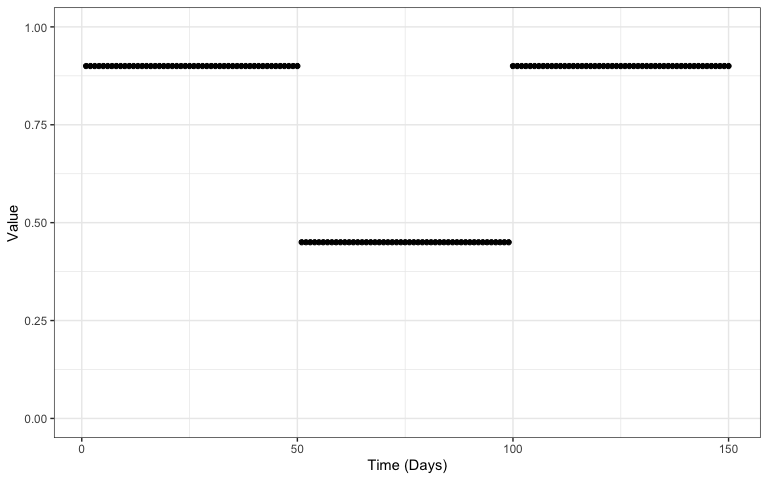

```r
ggplot(stepwise_df) +
  geom_point(mapping = aes(x = time, y = value)) +
  scale_y_continuous(name = "Value", limits = c(0, 1)) +
  scale_x_continuous(name = "Time (Days)") +
  theme_bw()
```

The time-varying case fatality risk function (`config$time_varying_death_risk`) which scales the hospitalised death risk (`hosp_death_risk`) and non-hospitalised death risk (`non_hosp_death_risk`) throughout the epidemic. In this case the risks are at their maximum, user-supplied, values from day 0 to day 50, and then half the risks from day 50 to day 100, and then return to their maximum value from day 100 onwards.

Simulating with the stepwise time-varying case fatality risk:

```r
linelist <- sim_linelist(
  contact_distribution = contact_distribution,
  infectious_period = infectious_period,
  prob_infection = 0.5,
  onset_to_hosp = onset_to_hosp,
  onset_to_death = onset_to_death,
  hosp_death_risk = 0.9,
  non_hosp_death_risk = 0.75,
  outbreak_size = c(500, 1000),
  config = config
)
head(linelist)
```

```
#>   id         case_name case_type sex age date_onset date_reporting
#> 1  1    Dang Autterson  probable   m  48 2023-01-01     2023-01-01
#> 2  2 Darrion Beauchamp  probable   m   4 2023-01-02     2023-01-02
#> 3  3     Alexis Geebro  probable   f  58 2023-01-07     2023-01-07
#> 4  6  Angelica Herrera confirmed   f  31 2023-01-02     2023-01-02
#> 5  7   Catherine Scott confirmed   f  77 2023-01-10     2023-01-10
#> 6  8      Mario Ibarra confirmed   m  62 2023-01-08     2023-01-08
#>   date_admission outcome date_outcome date_first_contact date_last_contact
#> 1           <NA>    died   2023-01-22               <NA>              <NA>
#> 2     2023-01-05    died   2023-02-05         2022-12-30        2023-01-01
#> 3     2023-01-09    died   2023-01-25         2023-01-01        2023-01-02
#> 4     2023-01-04    died   2023-01-13         2022-12-30        2023-01-06
#> 5           <NA>    died   2023-01-19         2023-01-04        2023-01-10
#> 6           <NA>    died   2023-02-12         2023-01-05        2023-01-11
#>   ct_value
#> 1       NA
#> 2       NA
#> 3       NA
#> 4     23.9
#> 5     19.9
#> 6     25.4
```

```r
linelist <- linelist %>%
  pivot_wider(
    names_from = outcome,
    values_from = date_outcome
  ) %>%
  rename(
    date_death = died,
    date_recovery = recovered
  )
```

```r
daily <- incidence(
  linelist,
  date_index = c(
    onset = "date_onset",
    death = "date_death"
  ),
  interval = "daily",
  complete_dates = TRUE
)
```

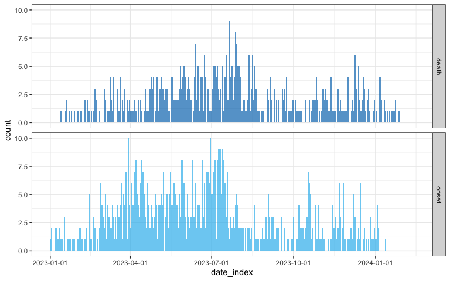

```r
plot(daily)
```

The maximum case fatality risk for hospitalised individuals is 0.9 and for non-hospitalised individuals is 0.75, and these rates remain constant from days 0 to 50, and then from days 50 to 100 the case fatality risk is halved (i.e `hosp_death_risk` = 0.45 and `non_hosp_death_risk` = 0.375), before going back to their original risks from day 100 onwards.”

This vignette does not explore applying a time-varying case fatality risk to age-stratified fatality risks, but this is possible with the `sim_linelist()` and `sim_outbreak()` functions. See the Age-stratified hospitalisation and death risks vignette and combine with instructions from this vignette on setting in a time-varying function using `create_config()`.

The implementation of the time-varying case fatality rate in the simulation functions (`sim_linelist()` and `sim_outbreak()`) is flexible to many functional forms. If there are other ways to have a time-varying case fatality risk that are not currently possible please make an [issue](https://github.com/epiverse-trace/simulist/issues) or [pull request](https://github.com/epiverse-trace/simulist/pulls). Currently the hospitalisation risk is assumed constant over time can cannot be adjusted to be time-varying like the death risk, if this is a feature you would like included in the {simulist} R package please make the request in an [issue](https://github.com/epiverse-trace/simulist/issues).